# ARIMA Models in R

A Primer for Turning Seasonal Messes into Leaderboard Points

Author

Calvin L.

Published

September 27, 2025

# 1 Time Series Data in `R`

You can directly obtain various time series data sets using the `timeSeriesDataSets` package. We will also need the `forecast` package in order to fit the ARIMA model into the dataset.

```r
library(forecast)
library(timeSeriesDataSets)

# Other libraries
library(tidyverse)
library(knitr)
```

## 1.1 Electricity Production Data

Consider the `elec_ts` data from the `timeSeriesDataSets` package. It provides monthly electricity output from 1956 to 1995. We provide a visualisation of the data below.

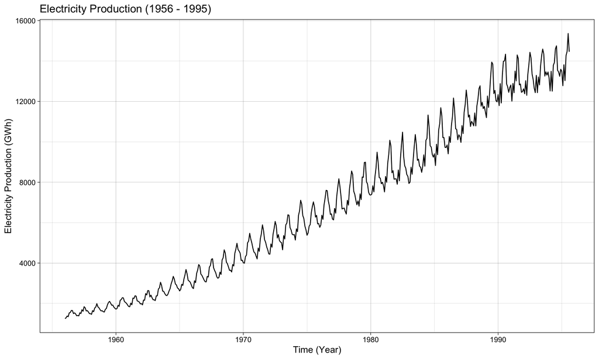

```r
x = elec_ts
autoplot(x) + labs(x = "Time (Year)", y = "Electricity Production (GWh)", title = "Electricity Production (1956 - 1995)") + theme_linedraw()
```

The data is not stationary, so we may have to resort to the ARIMA model via differencing, as opposed to an AR/MA/ARMA model, which require stationarity (and MA is stationary by definition). The `forecast` package has a function `auto.arima` which does this for us, so that we do not have to tweak $(p, d, q)$ ourselves.

## 1.2 ARIMA Model

```r
fit = auto.arima(x, stepwise = FALSE, approximation = FALSE, stationary = FALSE)
```

We can check residuals using `checkresiduals` and this tells us the residuals against time, the ACF of residuals, and their histogram. Based on these, we may want to tweak the model a bit, particularly with regards to the seasonal components, and deal with outliers by transformations. But that is left for another time.

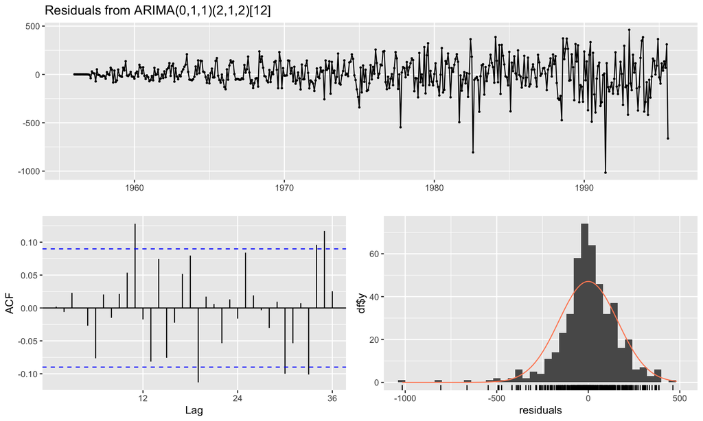

```
    Ljung-Box test

data:  Residuals from ARIMA(0,1,1)(2,1,2)[12]
Q* = 35.291, df = 19, p-value = 0.01288

Model df: 5.   Total lags used: 24
```

```r
checkresiduals(fit)
```

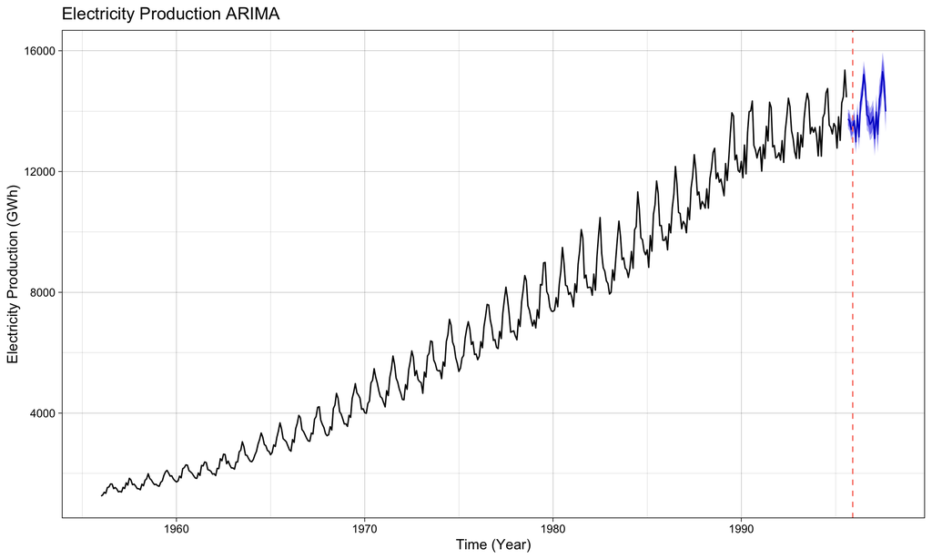

```r
fc = forecast(fit, h = 25)
autoplot(fc) + labs(x = "Time (Year)", y = "Electricity Production (GWh)", title = "Electricity Production ARIMA") + theme_linedraw() +
  geom_vline(xintercept = 1995 + 11/12, linetype = "dashed", color = "salmon")
```

## 1.3 Train-Test Split

We split the data and hold out the last $h$ periods to test our model based on the everything before that. This gives us a measure of how well our model would perform.

```r
h = 24 # 2 years
n = length(x)

x_train = window(x, end = time(x)[n - h])
x_test  = window(x, start = time(x)[n - h + 1])

fit = auto.arima(x_train)
fc  = forecast(fit, h = length(x_test))

# Metrics (Training + Test rows)
metrics = accuracy(fc, x_test) %>% round(3) %>% as.data.frame() %>% kable()
metrics
```

|  | ME | RMSE | MAE | MPE | MAPE | MASE | ACF1 | Theil’s U |
| --- | --- | --- | --- | --- | --- | --- | --- | --- |
| Training set | 2.207 | 157.271 | 109.979 | 0.023 | 1.774 | 0.323 | 0.000 | NA |
| Test set | -56.374 | 266.957 | 214.437 | -0.423 | 1.578 | 0.631 | 0.168 | 0.371 |

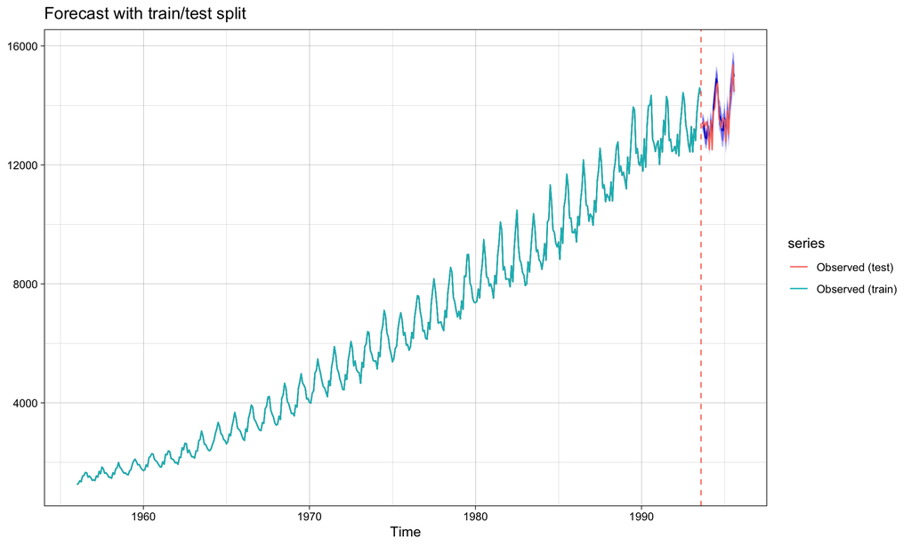

```r
cut_x = tail(time(x_train), 1)   # last observed time in the training set

autoplot(fc) +
  autolayer(x_train, series = "Observed (train)") +
  autolayer(x_test,  series = "Observed (test)") +
  geom_vline(xintercept = cut_x, linetype = "dashed", color = "salmon") +
  labs(title = "Forecast with train/test split",
       x = "Time", y = NULL) + theme_linedraw()
```